# Michael Hornsby’s EDRM 718 Final Project Script

Import the three data sets. (Note: some tidying was completed in Excel previously)

```
`as.tibble()` is deprecated, use `as_tibble()` (but mind the new semantics).
```

| ID | School Code | Age | Gender | Subject |
| --- | --- | --- | --- | --- |
| 778 | 2 | 22 | m | HUMANITIES |
| 459 | 1 | 21 | m | HUMANITIES |
| 208 | 5 | 22 | f | HUMANITIES |
| 342 | 10 | 22 | f | HUMANITIES |
| 718 | 9 | 22 | m | HUMANITIES |
| 824 | 18 | 21 | f | HUMANITIES |
| 734 | 15 | 22 | m | HUMANITIES |
| 477 | 9 | 22 | f | HUMANITIES |
| 424 | 23 | 22 | f | HUMANITIES |
| 577 | 11 | 22 | f | HUMANITIES |

[output cut: 729 more lines]

| ID | School Code | Age | Gender | S1Credits | S1GPA | S2Credits | S2GPA |
| --- | --- | --- | --- | --- | --- | --- | --- |
| 545 | 9 | 22 | f | 16 | 3.13 | 16 | 2.89 |
| 837 | 1 | 21 | m | 17 | 1.97 | 16 | 1.48 |
| 417 | 5 | 22 | m | 17 | 3.68 | 15 | 3.06 |
| 268 | 5 | 23 | m | 15 | 3.59 | 16 | 2.98 |
| 729 | 5 | 22 | f | 17 | 2.31 | 15 | 2.21 |
| 936 | 9 | 22 | f | 18 | 2.83 | 16 | 3.51 |
| 402 | 13 | 23 | m | 16 | 3.90 | 17 | 3.76 |
| 735 | 10 | 22 | f | 18 | 2.20 | 17 | 2.15 |
| 902 | 7 | 23 | f | 16 | 3.75 | 16 | 3.41 |
| 126 | 7 | 22 | m | 16 | 1.86 | 16 | 1.95 |

[output cut: 729 more lines]

| ID | Item1 | Item2 | Item3 | Item4 | Item5 | Item6 | Item7 | Item8 | Item9 | Item10 | Item11 | Item12 | Item13 | Item14 |
| --- | --- | --- | --- | --- | --- | --- | --- | --- | --- | --- | --- | --- | --- | --- |
| 653 | 2 | 5 | 5 | 3 | 4 | 4 | 6 | 5 | 5 | 2 | 5 | 2 | 1 | 6 |
| 478 | 2 | 1 | 5 | 4 | 1 | 4 | 5 | 6 | 5 | 3 | 5 | 2 | 4 | 3 |
| 247 | 5 | 5 | 6 | 3 | 6 | 2 | 4 | 5 | 4 | 5 | 6 | 2 | 4 | 5 |
| 934 | 4 | 3 | 3 | 3 | 1 | 2 | 3 | 6 | 4 | 2 | 3 | 3 | 4 | 6 |
| 971 | 4 | 6 | 3 | 5 | 3 | 1 | 3 | 2 | 4 | 2 | 2 | 3 | 5 | 2 |
| 750 | 1 | 6 | 4 | 5 | 5 | 3 | 5 | 5 | 4 | 3 | 4 | 4 | 5 | 3 |
| 919 | 4 | 6 | 1 | 5 | 1 | 3 | 2 | 3 | 4 | 4 | 4 | 4 | 1 | 2 |
| 306 | 4 | 5 | 4 | 5 | 4 | 3 | 3 | 2 | 4 | 2 | 5 | 1 | 1 | 2 |
| 389 | 3 | 1 | 1 | 2 | 5 | 5 | 3 | 6 | 3 | 5 | 2 | 2 | 2 | 5 |
| 859 | 6 | 3 | 4 | 5 | 5 | 4 | 4 | 3 | 5 | 6 | 1 | 1 | 1 | 6 |

[output cut: 523 more lines]

Let’s check the ID keys. I want to make sure there is no ID that appears more than once in the three datasets.

```r
check.demo <- demo %>% count(ID)
check.demo %>% filter(n > 1)
```

| ID | n |
| --- | --- |

```r
check.survey <- survey %>% count(ID)
check.survey %>% filter(n > 1)
```

| ID | n |
| --- | --- |

```r
check.GPA <- GPA %>% count(ID)
check.GPA %>% filter(n > 1)
```

| ID | n |
| --- | --- |
| 659 | 2 |

We see that ID 659 appears twice in the GPA dataset. Let’s look at these observations.

```r
GPA %>% filter(ID == 659)
```

| ID | School Code | Age | Gender | S1Credits | S1GPA | S2Credits | S2GPA |
| --- | --- | --- | --- | --- | --- | --- | --- |
| 659 | 5 | 22 | m | 18 | 3.08 | 16 | 2.77 |
| 659 | 4 | 21 | f | 15 | 3.05 | 17 | 2.97 |

If the ID was simply a duplicate observation I would only remove one of them. However, because the two are different, I’m going to remove both to be safe.

```r
GPA <- GPA %>% filter(ID != 659)

check.GPA <- GPA %>% count(ID)
check.GPA %>% filter(n > 1)
```

| ID | n |
| --- | --- |

I removed the two observations where the ID was 659. The number of observations in GPA dropped from 739 to 737, and I ran the check again just to make sure there were no duplicate ID’s.

Let’s move to examining student GPAs.

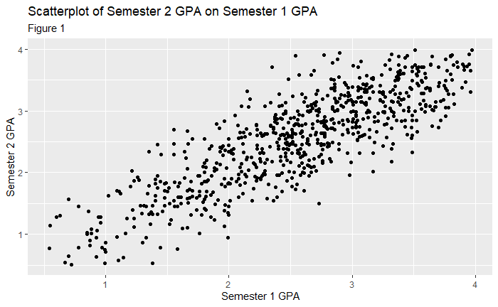

```r
ggplot(GPA, aes(x = S1GPA, y = S2GPA)) +
  geom_point() +
  labs(title = "Scatterplot of Semester 2 GPA on Semester 1 GPA",
       subtitle = "Figure 1",
       x = "Semester 1 GPA",
       y = "Semester 2 GPA")
```

I would consider this consistant within reason. The relationship between semester 2 gpa and semester 1 gpa looks linear. There looks to be a reasonable amount of deviate from what I would picture a best fit line to be, but no obvious outliers.

Let’s highlight the 10 percent largest residuals, and create the dataset that doesn’t have these largest residuals.

|  | key | xvar | yvar | residuals | outcome |
| --- | --- | --- | --- | --- | --- |
| 389 | 364 | 2.54 | 3.89 | 1.350934824 | TRUE |
| 442 | 377 | 2.35 | 3.71 | 1.330712697 | TRUE |
| 43 | 640 | 2.73 | 1.50 | -1.198843049 | TRUE |
| 289 | 662 | 2.77 | 3.90 | 1.167519504 | TRUE |
| 119 | 516 | 1.99 | 0.95 | -1.126550281 | TRUE |
| 505 | 660 | 2.15 | 3.32 | 1.108899932 | TRUE |
| 463 | 135 | 2.90 | 3.94 | 1.098197801 | TRUE |
| 698 | 925 | 3.17 | 2.02 | -1.048854966 | TRUE |
| 21 | 308 | 1.38 | 0.53 | -1.033579215 | TRUE |
| 618 | 553 | 2.48 | 3.51 | 1.021390994 | TRUE |

[output cut: 727 more lines]

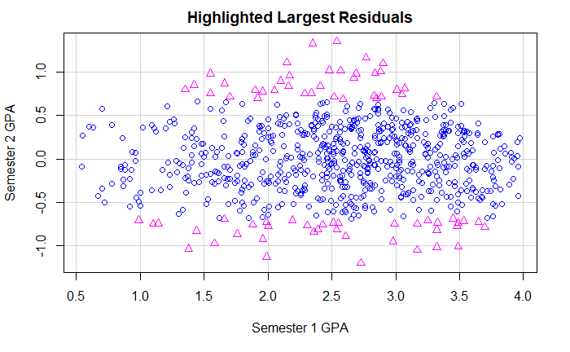

```r
resid.function(GPA$S1GPA, GPA$S2GPA, 74, GPA$ID)
```

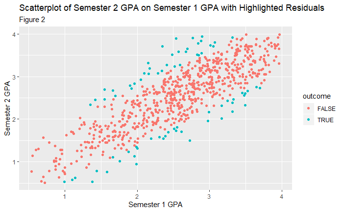

```r
ggplot(my_data, aes(x = xvar, y = yvar, color = outcome)) +
  geom_point() +
  labs(title = "Scatterplot of Semester 2 GPA on Semester 1 GPA with Highlighted Residuals",
       subtitle = "Figure 2",
       x = "Semester 1 GPA",
       y = "Semester 2 GPA")
```

```r
my_data$ID <- my_data$key

GPA <- my_data %>% left_join(GPA, by = "ID")
GPA <- GPA %>% filter(outcome == FALSE)
```

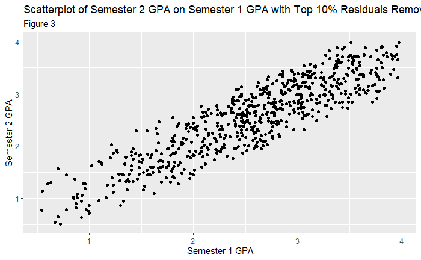

```r
ggplot(GPA, aes(x = xvar, y = yvar)) +
  geom_point() +
  labs(title = "Scatterplot of Semester 2 GPA on Semester 1 GPA with Top 10% Residuals Removed",
       subtitle = "Figure 3",
       x = "Semester 1 GPA",
       y = "Semester 2 GPA")
```

Let’s calculate GPA for the year

```r
GPA$year.GPA <-
  ((GPA$S1Credits * GPA$S1GPA) + (GPA$S2Credits * GPA$S2GPA)) / (GPA$S1Credits + GPA$S2Credits)
```

Let’s reverse score those appropriate survey items!

```r
reverse.function(survey, 6, c(4, 9, 12, 13))
```

| ID | Item1 | Item2 | Item3 | Item4 | Item5 | Item6 | Item7 | Item8 | Item9 | Item10 | Item11 | Item12 | Item13 | Item14 | survey.total |
| --- | --- | --- | --- | --- | --- | --- | --- | --- | --- | --- | --- | --- | --- | --- | --- |
| 653 | 2 | 5 | 5 | 3 | 4 | 4 | 6 | 5 | 5 | 2 | 5 | 2 | 1 | 6 | 61 |
| 478 | 2 | 1 | 5 | 4 | 1 | 4 | 5 | 6 | 5 | 3 | 5 | 2 | 4 | 3 | 48 |
| 247 | 5 | 5 | 6 | 3 | 6 | 2 | 4 | 5 | 4 | 5 | 6 | 2 | 4 | 5 | 64 |
| 934 | 4 | 3 | 3 | 3 | 1 | 2 | 3 | 6 | 4 | 2 | 3 | 3 | 4 | 6 | 47 |
| 971 | 4 | 6 | 3 | 5 | 3 | 1 | 3 | 2 | 4 | 2 | 2 | 3 | 5 | 2 | 39 |
| 750 | 1 | 6 | 4 | 5 | 5 | 3 | 5 | 5 | 4 | 3 | 4 | 4 | 5 | 3 | 49 |
| 919 | 4 | 6 | 1 | 5 | 1 | 3 | 2 | 3 | 4 | 4 | 4 | 4 | 1 | 2 | 44 |
| 306 | 4 | 5 | 4 | 5 | 4 | 3 | 3 | 2 | 4 | 2 | 5 | 1 | 1 | 2 | 51 |
| 389 | 3 | 1 | 1 | 2 | 5 | 5 | 3 | 6 | 3 | 5 | 2 | 2 | 2 | 5 | 55 |
| 859 | 6 | 3 | 4 | 5 | 5 | 4 | 4 | 3 | 5 | 6 | 1 | 1 | 1 | 6 | 58 |

[output cut: 523 more lines]

```r
survey <- dataset.tot
```

The individual item responses in the output table above remain the same as in the original data, however the total column at the end factors in the reverse score of the items. Let’s left join the total onto the GPA data.

```r
survey.tot <- survey[,c(1,16)]
GPA <- survey.tot %>% left_join(GPA, by = "ID")
```

We need to get the subject onto the GPA dataset so the GPA dataset will be ready for use in all data analysis relevant to our three main research questions. A left join is used here as well.

```r
demo.sub <- demo[,c(1,5)]
GPA <- demo.sub %>% left_join(GPA, by = "ID")
```

The last step for getting the GPA dataset ready for our analysis is to drop the observations with missing data.

```r
GPA <- GPA[complete.cases(GPA),]
```

Alright, we have 478 complete observations in our GPA dataset for which to perform out analysis.

Let’s start with the research questions regarding whether GPA is related to optimism about future employement. Let’s start by looking at a scatterplot of this relationship with a best fit line.

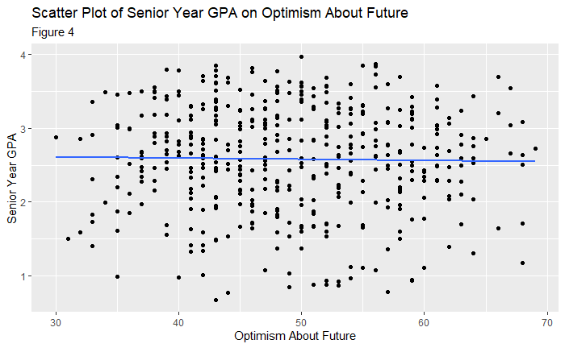

```r
GPA %>%
  ggplot(aes(x = survey.total, y = year.GPA)) +
  geom_point() +
  stat_smooth(method = lm, se = FALSE) +
  labs(title = "Scatter Plot of Senior Year GPA on Optimism About Future",
       subtitle = "Figure 4",
       x = "Optimism About Future",
       y = "Senior Year GPA")
```

```r
GPAonOPT.mod <- lm(year.GPA ~ survey.total, data = GPA)
summary(GPAonOPT.mod)
```

```
Call:
lm(formula = year.GPA ~ survey.total, data = GPA)

Residuals:
     Min       1Q   Median       3Q      Max
-1.91420 -0.45387  0.05722  0.53168  1.39724

Coefficients:
              Estimate Std. Error t value Pr(>|t|)
(Intercept)   2.659505   0.192156  13.840   <2e-16 ***
survey.total -0.001635   0.003865  -0.423    0.672
---
Signif. codes:  0 ‘***’ 0.001 ‘**’ 0.01 ‘*’ 0.05 ‘.’ 0.1 ‘ ’ 1

Residual standard error: 0.7097 on 476 degrees of freedom
Multiple R-squared:  0.0003758, Adjusted R-squared:  -0.001724
F-statistic: 0.1789 on 1 and 476 DF,  p-value: 0.6725
```

Well, we see that in our model that survey.total has p-value of 0.672 that is not significant at any reasonable alpha level. (I did briefly explore a higher order relationship just to check, but that wasn’t helpful.) I cannot conclude that senior year GPA is related to degree of optimism about future employement. Considering we have to use these two variables for further research questions, I want to check a qqplot for both of these variables.

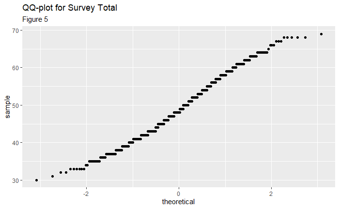

```r
GPA %>%
  ggplot() +
  geom_qq(aes(sample = survey.total)) +
  labs(title = "QQ-plot for Survey Total",
       subtitle = "Figure 5")
```

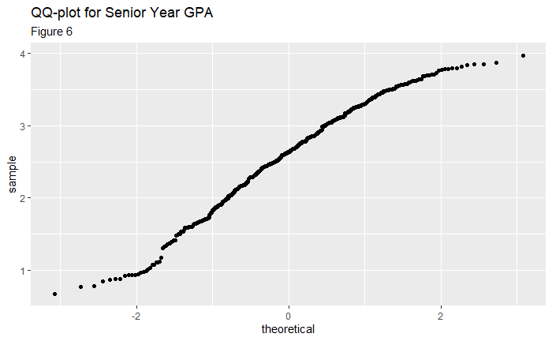

```r
GPA %>%
  ggplot() +
  geom_qq(aes(sample = year.GPA)) +
  labs(title = "QQ-plot for Senior Year GPA",
       subtitle = "Figure 6")
```

Well, neither of these look spectacular, but I think it is safe enough to continue with our analysis regarding the rest of the research questions. Let’s look to see if there is an interaction effect between the degree of optimism and subject.

```r
model.interaction <- aov(GPA$year.GPA ~ GPA$survey.total*GPA$Subject)
Anova(model.interaction)
```

```
Anova Table (Type II tests)

Response: GPA$year.GPA
                              Sum Sq  Df F value Pr(>F)
GPA$survey.total               0.105   1  0.2065 0.6497
GPA$Subject                    1.972   4  0.9739 0.4214
GPA$survey.total:GPA$Subject   0.858   4  0.4235 0.7917
Residuals                    236.922 468
```

```r
model.maineffects <- aov(GPA$year.GPA ~ GPA$survey.total+GPA$Subject)
Anova(model.maineffects)
```

```
Anova Table (Type II tests)

Response: GPA$year.GPA
                  Sum Sq  Df F value Pr(>F)
GPA$survey.total   0.105   1  0.2075 0.6489
GPA$Subject        1.972   4  0.9787 0.4188
Residuals        237.780 472
```

The p-values here are all disappointing. None of these p-value are significant at any reasonable alpha level. This would suggest that not only is the interaction between optimism and subject not significant, neither of the main effects are significant predictors of senior year GPA either. Let’s look at a plot just to make sure.

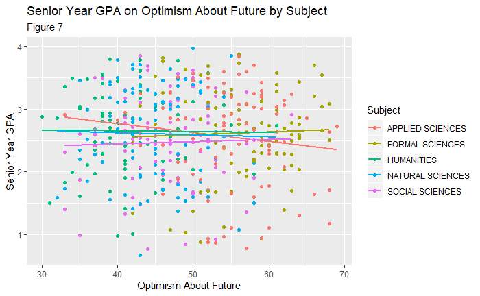

```r
GPA %>%
  ggplot(aes(x = survey.total, y = year.GPA, color = Subject)) +
  geom_point(aes(color = Subject)) +
  stat_smooth(method = lm, se = FALSE) +
  labs(title = "Senior Year GPA on Optimism About Future by Subject",
       subtitle = "Figure 7",
       x = "Optimism About Future",
       y = "Senior Year GPA")
```

The plot looks about as expected after the ANCOVA results and knowing what the first scatterplot looked like. The relationship between senior year GPA and optimism about the future is fairly consistant for all categories of desciplines.

Let’s look at boxplots for levels of optimism about the future for each subject before we look at the ANOVA.

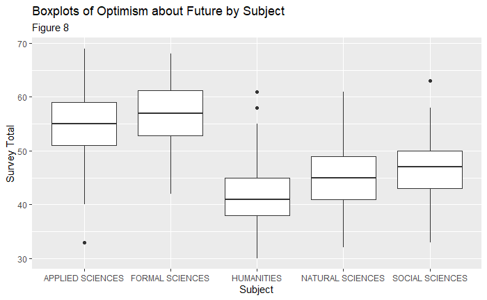

```r
GPA %>%
  ggplot(aes(x = Subject, y = survey.total)) +
  geom_boxplot() +
  labs(title = "Boxplots of Optimism about Future by Subject",
       subtitle = "Figure 8",
       x = "Subject",
       y = "Survey Total")
```

There does look to be some differences here. I think we can safely assume our assumptions are met here. Survey total looked close enough to normal and our variances look mostly equal among subjects. Let’s run the ANOVA and see what happens.

```r
my.anova <- aov(survey.total ~ Subject, data = GPA)
my.anova.result <- anova(my.anova)
my.anova.result
```

```
Analysis of Variance Table

Response: survey.total
           Df Sum Sq Mean Sq F value    Pr(>F)
Subject     4  16559  4139.7   114.1 < 2.2e-16 ***
Residuals 473  17161    36.3
---
Signif. codes:  0 ‘***’ 0.001 ‘**’ 0.01 ‘*’ 0.05 ‘.’ 0.1 ‘ ’ 1
```

Well, our omnibus test here has a significant p-value at the alpha = 0.05 confidence level. This would suggest that at least one subject mean is different than the others. Let’s look at all of our pairwise comparisons while keeping out family-wise confidence level at 95%.

```r
TukeyHSD(my.anova)
```

```
  Tukey multiple comparisons of means
    95% family-wise confidence level

Fit: aov(formula = survey.total ~ Subject, data = GPA)

$Subject
                                        diff         lwr        upr     p adj
FORMAL SCIENCES-APPLIED SCIENCES    1.827527  -0.5485847   4.203638 0.2191046
HUMANITIES-APPLIED SCIENCES       -13.528837 -15.9817722 -11.075901 0.0000000
NATURAL SCIENCES-APPLIED SCIENCES  -9.932077 -12.3025137  -7.561640 0.0000000
SOCIAL SCIENCES-APPLIED SCIENCES   -8.371640 -10.7714862  -5.971793 0.0000000
HUMANITIES-FORMAL SCIENCES        -15.356364 -17.7671972 -12.945530 0.0000000
NATURAL SCIENCES-FORMAL SCIENCES  -11.759604 -14.0864464  -9.432761 0.0000000
SOCIAL SCIENCES-FORMAL SCIENCES   -10.199167 -12.5559630  -7.842370 0.0000000
NATURAL SCIENCES-HUMANITIES         3.596760   1.1915191   6.002000 0.0004754
SOCIAL SCIENCES-HUMANITIES          5.157197   2.7229670   7.591427 0.0000001
SOCIAL SCIENCES-NATURAL SCIENCES    1.560437  -0.7906375   3.911512 0.3646360
```

These pairwise comparisons echo what is demonstrated in the boxplots above. Applied and formal sciences have the highest optimism about the future, with humanities having much lower optimist about the future.